# Validação

## Posicionamento Político

Esta experimento diz respeito à diferença de subjetividade associada aos portais com posicionamento político declarado e não declarado. Em outras palavras, separamos os portais com posicionamento declarado (ou seja, VEJA, Carta Capital e O Antagonista) daqueles cuja o posicionamento político não é declarado. Intuitivamente, pode-se esperar que os portais com posicionamento político declarado apresentem maior subjetividade em suas notícias, quando comparados aos posicionamentos não declarados, devido à idéia de expor suas opiniões sobre os fatos relatados.

```r
pos_pol <- bind_rows(
    "definido" = carta_capital,
    "indefinido" = el_pais,
    "indefinido" = estadao,
    "indefinido" = folha,
    #"indefinido" = gazeta_do_povo,
    "definido" = oantagonista,
    "indefinido" = oglobo,
    "definido" = veja,
    .id = "posicionamento_politico") %>%
    mutate(bias_news = (1 - (arg + sen + val + pre + mod) / 5)) %>%
    select(posicionamento_politico, bias_news)

resamples = 2000

subj_def <- pos_pol %>%
  filter(posicionamento_politico == "definido") %>%
  bootstrap(median(bias_news),
            R = resamples) %>%
    CI.percentile(probs = c(.025, .975))

subj_indef <- pos_pol %>%
  filter(posicionamento_politico == "indefinido") %>%
  bootstrap(median(bias_news),
            R = resamples) %>%
    CI.percentile(probs = c(.025, .975))

subj_ci = data.frame(rbind(subj_def, subj_indef))

subj_ci$jornal = c("Declared Position", "Non-Declared Position")
```

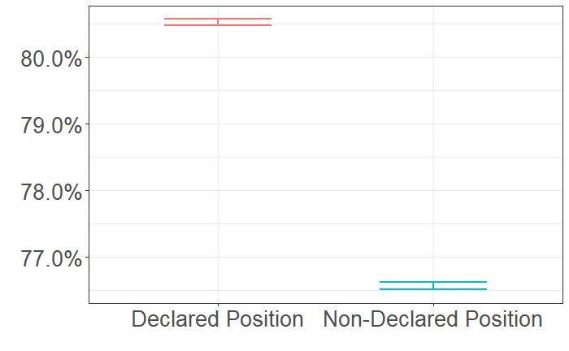

```r
vld2 <- subj_ci %>%
  ggplot(aes(x = jornal, ymin = X2.5., ymax = X97.5., color = jornal)) +
  geom_errorbar(width = .5, size = .8) +
  labs(#title = "Percentual de subjetividade por portal",
       #subtitle = "Estimativa de subjetividade considerando todas as notícias de 2018",
       x = "",
       y = "") +
  scale_y_continuous(labels = scales::percent) +
  theme_bw() +
  theme(legend.position="none",
        axis.text=element_text(size=20),
        plot.title = element_text(size=22)
        )
vld2
ggsave("fig1.pdf", width = 8, height = 6)
```

```r
#ggarrange(a, qp1,
#          labels = c("A", "B"),
#          ncol = 2)
#ggsave("fig0-1.pdf", width = 12, height = 4)
```

Esses resultados reforçam nossa hipótese de que os portais com posicionamento declarado apresentam níveis de subjetividade mais altos em suas notícias do que portais que não possuem posicionamento declarado e atestam a eficiência de nosso método de capturar a subjetividade presente em notícias.